# Part II - (Ford GoBike System Data )

## by OLUGBENGA FEYISAYO CHARLES

## Investigation Overview

I will be focusing on the age distribution of the riders, while also showing other categorical variables. Showing how they correlate with the numerical values is also visualized. It is obvious that majority of the numerical values are not correlating with one another, but how they correlate with the categorical values will be shown.

## Dataset Overview

```python
# import all packages and set plots to be embedded inline
import numpy as np
import pandas as pd
import matplotlib.pyplot as plt
import seaborn as sb

%matplotlib inline

# suppress warnings from final output
import warnings
warnings.simplefilter("ignore")
```

```python
# load in the dataset into a pandas dataframe
# from the exploratory section i saved the cleaned dataframe to a new csv file and that is what I am going to load here

df2 = pd.read_csv('bike_sharing_cleaned.csv')
df2.head()
```

|  | start_station_name | end_station_name | bike_id | user_type | member_birth_year | member_gender | day | month | member_age | duration_min | age_group |
| --- | --- | --- | --- | --- | --- | --- | --- | --- | --- | --- | --- |
| 0 | Montgomery St BART Station (Market St at 2nd St) | Commercial St at Montgomery St | 4902 | Customer | 1984 | Male | 28 | Feb | 35 | 870 | young |
| 1 | Market St at Dolores St | Powell St BART Station (Market St at 4th St) | 5905 | Customer | 1972 | Male | 28 | Feb | 47 | 1031 | young |
| 2 | Grove St at Masonic Ave | Central Ave at Fell St | 6638 | Subscriber | 1989 | Other | 28 | Feb | 30 | 609 | very_young |
| 3 | Frank H Ogawa Plaza | 10th Ave at E 15th St | 4898 | Subscriber | 1974 | Male | 28 | Feb | 45 | 27 | young |
| 4 | 4th St at Mission Bay Blvd S | Broadway at Kearny | 5200 | Subscriber | 1959 | Male | 28 | Feb | 60 | 30 | young |

> Note that the above cells have been set as "Skip"-type slides. That means that when the notebook is rendered as http slides, those cells won't show up.

## Age Distribution of Riders

Riders have ages that range from 18 to 141. However ages above 100 apper to be outliers, because that seem to be an impossible feat. Images below show the distribution of the age, and what it looks like after grouping the ages into different categories.

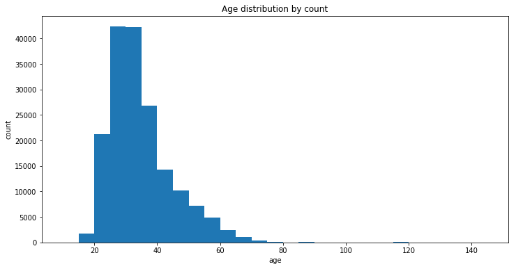

```python
binsize = 5
bins = range(10, df2.member_age.max() + 5, 5)

plt.figure(figsize = [12, 6])
plt.hist(data = df2, x = 'member_age', bins = bins)
plt.xlabel('age')
plt.ylabel('count')
plt.title('Age distribution by count')
plt.show()
```

```python
df2['age_group'] = pd.cut(df2['member_age'],[0, 30, 60, 90, 120, 150],
                                labels=['very_young', 'young', 'old', 'very_old', 'Extremely_old'])
```

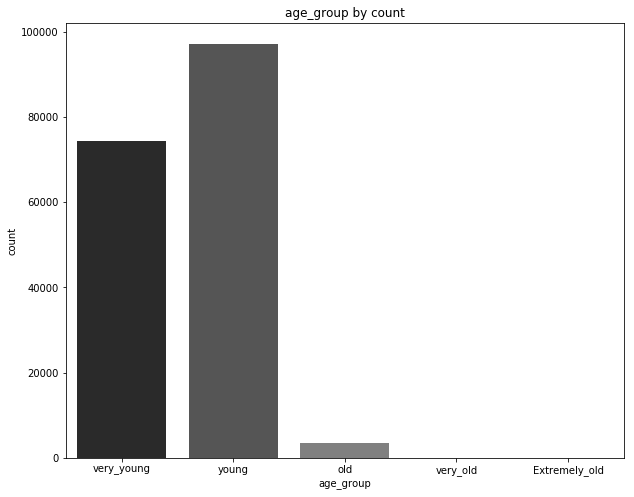

```python
plt.figure(figsize=(10,8))
sb.countplot(data= df2, x = 'age_group', palette = 'gray')
plt.xlabel('age_group')
plt.ylabel('count')
plt.title('age_group by count');
```

## Correlation between numeric values within the dataset

The numeric values of the dataste do not correlate with each other completely, however there is a negative correlation between age and birth year as expected. With time, there is no correlation with other variables in the dataset, which means the time spent during each rides is independent of any factor or numerical variable.

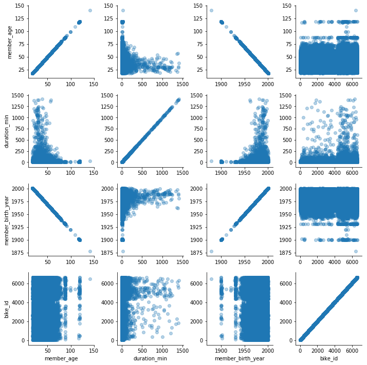

```python
data_stat = ['member_age', 'duration_min', "member_birth_year", "bike_id"]
g = sb.PairGrid(data = df2, vars = data_stat);
g.map(plt.scatter, alpha = 1/3);
```

## Correlation of all variables in the dataset using heatmap

The correlation of the variables in the datset is shown in the heatmap below. It clearly confirms our observation above and makes it clear enough the independency of duration of bike rides in relation to other variables.

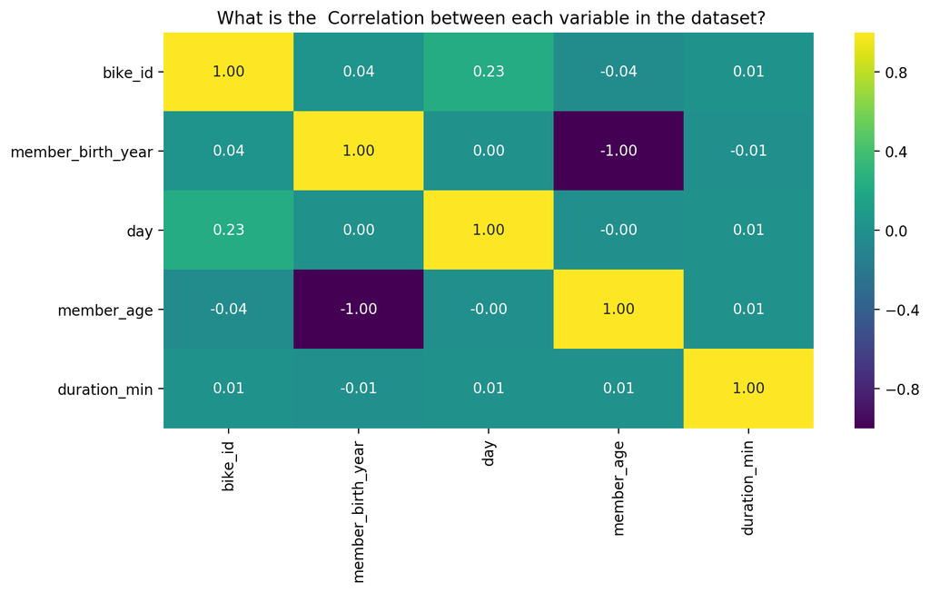

```python
plt.figure(figsize = (10,5), dpi = 200)
sb.heatmap(df2.corr(), annot = True, fmt = '.2f', cmap = 'viridis', center = 0)

plt.title(" What is the  Correlation between each variable in the dataset?")
plt.xticks(rotation = 90)
plt.legend(bbox_to_anchor=(1.05, 1), loc='upper left')
plt.show()
```

```python
# Use this command if you are running this file in local
!jupyter nbconvert Part_II_slide_deck_template.ipynb --to slides --post serve --no-input --no-prompt
```

[output not shown]